# Investigate Titanic Data Set

In this project we are going to work with the Titanic passenger data. We are interested to find out if there is any correlation between any of the data items. It makes me curious to know if we can make any conclusion about how the survival rate could be increased.

The steps I am going to follow are:

```
(i) visually inspect the data and find out if the dataset has any missing pieces,

(ii) gather various data propoerties, plot the extracted information visually as applicable to present the findings.
```

```python
import numpy as np
import pandas as pd
%pylab inline
import matplotlib.pyplot as plt
import seaborn as sns
```

At the beginning I am going to examine a few rows in the dataset to see how the data has been collected/stored, if there are missing data, etc.

```python
""" Read the Titanic data from the .csv file """
titanic_df = pd.read_csv('titanic-data.csv')

""" Inspect the first few rows of the dataframe """
print titanic_df.head(10)
```

```
   PassengerId  Survived  Pclass  \
0            1         0       3
1            2         1       1
2            3         1       3
3            4         1       1
4            5         0       3
5            6         0       3
6            7         0       1
7            8         0       3
8            9         1       3
9           10         1       2

                                                Name     Sex   Age  SibSp  \
0                            Braund, Mr. Owen Harris    male  22.0      1
1  Cumings, Mrs. John Bradley (Florence Briggs Th...  female  38.0      1
```

[output cut: 20 more lines]

As we see, there are NaN in the 'Age' and 'Cabin' data. This poses some limitation on how accurately we can analyze this data and try to find correlation between various variables. However, we will try to do our best with such limiation by eliminating these NaNs before being analysed.

## Gather preliminary statistics

As a next step I am going to gather some statistics about the passengers:

• Total number of passengers

• Total number of female and male passengers

• Total number of people survived

• Number of female and male survivors

• Number of female and male deaths

```python
no_of_passengers = titanic_df['PassengerId'].count()
print 'Total number of passengers = {}'.format(no_of_passengers)

no_of_females = (titanic_df[titanic_df['Sex'] == 'female'])['Sex'].count()
print 'Total number of females = {}'.format(no_of_females)

no_of_males = (titanic_df[titanic_df['Sex'] == 'male'])['Sex'].count()
print 'Total number of males = {}'.format(no_of_males)

no_of_survivors = (titanic_df[titanic_df['Survived'] == 1])['Survived'].count()
print 'Total number of people survived = {}'.format(no_of_survivors)

no_of_non_survivors = (titanic_df[titanic_df['Survived'] == 0])['Survived'].count()
print 'Total number of people died = {}'.format(no_of_non_survivors)

female_survivors = titanic_df[(titanic_df['Sex'] == 'female') & (titanic_df['Survived'] == 1)]
no_of_female_survivors = female_survivors['PassengerId'].count()
print 'Total number of female survivors = {}'.format(no_of_female_survivors)

female_deaths = titanic_df[(titanic_df['Sex'] == 'female') & (titanic_df['Survived'] == 0)]
no_of_female_deaths = female_deaths['PassengerId'].count()
print 'Total number of female deaths = {}'.format(no_of_female_deaths)

male_survivors = titanic_df[(titanic_df['Sex'] == 'male') & (titanic_df['Survived'] == 1)]
no_of_male_survivors = male_survivors['PassengerId'].count()
print 'Total number of male survivors = {}'.format(no_of_male_survivors)

male_deaths = titanic_df[(titanic_df['Sex'] == 'male') & (titanic_df['Survived'] == 0)]
no_of_male_deaths = male_deaths['PassengerId'].count()
print 'Total number of male deaths = {}'.format(no_of_male_deaths)
```

```
Total number of passengers = 891
Total number of females = 314
Total number of males = 577
Total number of people survived = 342
Total number of people died = 549
Total number of female survivors = 233
Total number of female deaths = 81
Total number of male survivors = 109
Total number of male deaths = 468
```

## Investigate passengers by Age

I was curious to know the age group of the passengers. So I wanted to focus on this data and understand its distribution. As noted earlier, there are some missing data. Hence, I needed to eliminate such records before processing.

```
7
Minimum age of the passengers = 0.42
Maximum age of the passengers = 80.0
Average age of the passengers = 29.6991176471
```

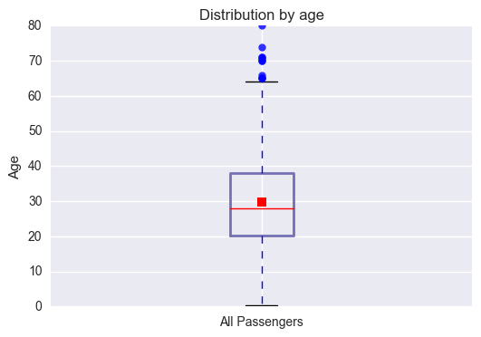

```python
""" Look at the age distribution of the passengers """
""" How many 1-year old children were there """
print (titanic_df[titanic_df['Age'] == 1.0])['Age'].count()

""" The Age data contains NaNs. We need to remove the NaNs from the age data.
    Create a new dataframe from titanic_df after removing the the NaNs in the 'Age' column.
"""
df_age = titanic_df.dropna(subset = ['Age'])
age_series = df_age['Age']

""" What are the min, max and average age of the Titanic passengers? """
print "Minimum age of the passengers = {}".format(age_series.min())
print "Maximum age of the passengers = {}".format(age_series.max())
print "Average age of the passengers = {}".format(age_series.mean())

""" Maybe we should view the passenger information by age through a box plot. """
bp = plt.boxplot(age_series, showmeans = True, labels = ['All Passengers'])
plt.title("Distribution by age")
plt.ylabel('Age')
for flier in bp['fliers']:
    flier.set(marker='o', color='#e7298a', alpha=0.8)
for box in bp['boxes']:
    box.set(color='#7570b3', linewidth=2)
```

It looks like the passengers are fairly young! The average age (red rectangle), and the median age (red line inside the box) are below or around 30!). There are also months old and very senior passengers travelling.

Now trying to find out where the passengers embarked the Titanic.

## Investigate passengers by their port of embarkation

```
Passengers embarked at Cherbourg = 168
Passengers embarked at Queenstown = 77
Passengers embarked at Southampton = 644
```

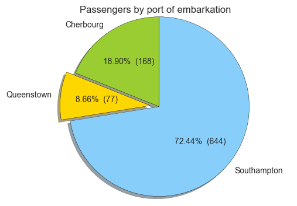

```python
""" Investigatig passengers embarking from various ports """

""" Since we will be focusing on the 'Embarked' column of the dataframe, we will start
    with removing the NaNs in this column. Use the 'dropna' API to create a new dataframe.
"""
titanic_df_embarked = titanic_df.dropna(subset = ['Embarked'])

""" The following variables designate the number of passengers embarking from various ports """
passengers_C = (titanic_df_embarked[titanic_df_embarked['Embarked'] == 'C'])['PassengerId'].count()
passengers_Q = (titanic_df_embarked[titanic_df_embarked['Embarked'] == 'Q'])['PassengerId'].count()
passengers_S = (titanic_df_embarked[titanic_df_embarked['Embarked'] == 'S'])['PassengerId'].count()
print "Passengers embarked at Cherbourg = {}".format(passengers_C)
print "Passengers embarked at Queenstown = {}".format(passengers_Q)
print "Passengers embarked at Southampton = {}".format(passengers_S)

""" Draw a pie-chart with the port of embarkation statistics.
    matplotlib provides a convenient way to denote the percentage number.
    However, by default, the plot does not include the actual value for display.
"""

"""
    Function: make_autopct
    Purpose: Customize the ability to display the percentage information in a specific format.
    Input: The values to be plotted (use these values to calculate the sum total).
    Defines: Another function 'pct_and_value' that recieves the percentage number from plt
           and returns back a label to plt
    output: Returns the pointer to the function 'pct_and_value'. This funtion is used by plt to
           display a label on the pie.
    (Courtesey: Suggestion by the reviewer)
"""
def make_autopct(values):
    total = sum(values)
    def pct_and_value(pct):
        val = int(round(pct*total/100.0))
        return '{p:.2f}%  ({v:d})'.format(p=pct,v=val)
    return pct_and_value

labels = 'Cherbourg', 'Queenstown', 'Southampton'
sizes = [passengers_C, passengers_Q, passengers_S]
colors = ['yellowgreen', 'gold', 'lightskyblue']

""" Only "explode" the 2nd slice, i.e. 'Queenstown' passengers """
explode = (0, 0.1, 0)
plt.pie(sizes, explode=explode, labels=labels, colors=colors,
        autopct=make_autopct(sizes), shadow=True, startangle=90)

plt.title('Passengers by port of embarkation')
""" Set aspect ratio to be equal so that pie is drawn as a circle """
plt.axis('equal')
plt.show()
```

Passengers are not all travelling alone. They have family members with them - their siblings, parents and children. It is a perfect time for all to spend time together for days-long journey on-board. They were looking forward to a very pleasant and safe sea voyage!

## Passengers traveling with family members

```python
""" Passengers travelling with family members.
    The data about the family members are tabluated in the 'SibSp' (Sibling or Spouse)
    and the 'Parch' (Parent or Child) columns in the table.
"""

""" Create a new dataframe after removing the NaNs in the 'SibSp' and 'Parch' fields, if any.
    As in the past, use the 'dropna' API to create a new dataframe with only 'finite' values
    in the 'SibSp' and 'Parch' columns.
"""
titanic_df_families = titanic_df.dropna(subset = ['SibSp', 'Parch'])

""" Add a column with the count of family members to our datafrae """
titanic_df_families['Family'] = titanic_df_families['SibSp'] + titanic_df_families['Parch']

""" Get a statistical description of the 'Family' column (family informaiton)"""
print titanic_df_families['Family'].describe()
```

```
count    891.000000
mean       0.904602
std        1.613459
min        0.000000
25%        0.000000
50%        0.000000
75%        1.000000
max       10.000000
Name: Family, dtype: float64
```

```python
""" The largest family is of size 10. Lets find out more about these passengers """
print titanic_df_families[titanic_df_families['Family']==10]
```

```
     PassengerId  Survived  Pclass                               Name     Sex  \
159          160         0       3         Sage, Master. Thomas Henry    male
180          181         0       3       Sage, Miss. Constance Gladys  female
201          202         0       3                Sage, Mr. Frederick    male
324          325         0       3           Sage, Mr. George John Jr    male
792          793         0       3            Sage, Miss. Stella Anna  female
846          847         0       3           Sage, Mr. Douglas Bullen    male
863          864         0       3  Sage, Miss. Dorothy Edith "Dolly"  female

     Age  SibSp  Parch    Ticket   Fare Cabin Embarked  Family
159  NaN      8      2  CA. 2343  69.55   NaN        S      10
180  NaN      8      2  CA. 2343  69.55   NaN        S      10
201  NaN      8      2  CA. 2343  69.55   NaN        S      10
324  NaN      8      2  CA. 2343  69.55   NaN        S      10
792  NaN      8      2  CA. 2343  69.55   NaN        S      10
846  NaN      8      2  CA. 2343  69.55   NaN        S      10
863  NaN      8      2  CA. 2343  69.55   NaN        S      10
```

Next, I am going to examine the survival data and find out if luck favored any gender.

## Survival information of passengers by gender

```
Total no. of people survived = 342
Total no. of people died = 549


Dataframe of survival figures based on gender
Survived  Sex
0         female     81
          male      468
1         female    233
          male      109
Name: PassengerId, dtype: int64


Dataframe Alive/dead
        Alive  Dead
Sex
female    233    81
male      109   468

Dataframe: Percentage of passengers by gender
            Alive       Dead
Sex
female  68.128655  14.754098
male    31.871345  85.245902
```

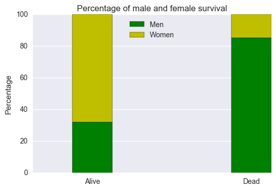

```python
""" Let us explore the passengers that survived or did not """
survived_or_not = (titanic_df.groupby('Survived'))['PassengerId'].count()
survived = survived_or_not.loc[1]
not_survived = survived_or_not.loc[0]
print 'Total no. of people survived = {}'.format(survived)
print 'Total no. of people died = {}'.format(not_survived)
print ""
print ""

""" Create a dataframe for survival figures based on passenger gender """
survived_or_not_by_gender = titanic_df.groupby(['Survived', 'Sex'])
survived_or_not_by_gender_df = survived_or_not_by_gender['PassengerId'].count()
print "Dataframe of survival figures based on gender"
print survived_or_not_by_gender_df
print ""
print ""

""" Create a new simplified dataframe with gender-based survival information """
alive = pd.Series(survived_or_not_by_gender_df.loc[1])
dead = pd.Series(survived_or_not_by_gender_df.loc[0])
survival_df = pd.DataFrame({'Alive':alive, 'Dead':dead})
print "Dataframe Alive/dead"
print survival_df
print ""

""" Convert this dataframe to reflect the percentage information """
survival_df_percent = (survival_df/survival_df.sum())*100
print "Dataframe: Percentage of passengers by gender"
print survival_df_percent
print ""

""" Create slices of male and female survivals for plotting """
survival_df_percent_male = survival_df_percent.loc['male']
survival_df_percent_female = survival_df_percent.loc['female']

""" Plot a stacked_bar for the passengers """
X = np.array([1.0, 1.2])
width = 0.05

p1 = plt.bar(X, survival_df_percent_male , width, color = 'g')
p2 = plt.bar(X, survival_df_percent_female, width, color = 'y', bottom = survival_df_percent_male)

plt.ylabel('Percentage')
plt.title("Percentage of male and female survival")
plt.legend((p1[0], p2[0]), ('Men', 'Women'), loc = 'upper center')
plt.xticks(X + width/2., ('Alive', 'Dead'))
plt.show()
```

The above stacked bar plot shows a comparison of the alive and dead passengers by gender. We notice that the female survival was more that that of male.

Next we are going to find out if there is any correlation between the survival and the passengers' age.

## Survival figures by age

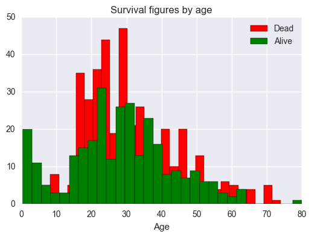

```python
""" Create a new dataframe after removing the NaNs in the 'Age' column.
    This is necessary since we will be processing the age information for this purpose.
"""
titanic_df_by_age = titanic_df.dropna(subset = ['Age'])

""" Create a series with age for those who survived """
survived_by_age = (titanic_df_by_age[titanic_df_by_age['Survived'] == 1])['Age']

""" Create a series with age for those who did not survive """
survived_not_by_age = (titanic_df_by_age[titanic_df_by_age['Survived'] == 0])['Age']

""" See how they comapre with histograms """
plt.hist(survived_not_by_age, bins = 30, color = 'r', label = 'Dead')
plt.hist(survived_by_age, bins = 30, color = 'g', label = 'Alive')
plt.xlabel('Age')
plt.legend(loc = 'upper right')
plt.title("Survival figures by age")
```

The plot shows that very young (less than 10) and very aged (~80) passengers survived. Maybe they were given priorites to take up the boats. A large number of young passengers did not survive, maybe because they gave away to younger/older people to be rescued first.

## Limitation

The Titanic dataset has some limitations. The missing values in some cases, e.g. age, cabin etc. likely makes the analysis incomplete, to some extent. Based on the analysis, one would tend to infer a correlation between age and the rate of survival. However, based on some missing data, drawing such conclusions could be erroneous. The statistical population (all Titanic passengers) parameters are known in this case. A z-test could possibly be conducted to establish if there is really a relationship between the the age and the survival rate. In absence of such statistical test, we will not make any inferences about the causation.

The dataset did not include the number of lifeboats available. If this number was available, then we could conclude if the boats were sufficient or not for these many passengers.

## Conclusion

In this project, we have analyzed the Titanic passengers data and tried to find out if there is any insight we can get to correlate to the survival rate. The average and median age of the passengers were about 30. There were a few babies and aged people among the passengers. There were also large families travelling in the ship.

Analysis shows that more than half of the passengers perished. The analysis also shows that there are more female survivors than the male survivors. Besides, the age distribution data shows that more young people died, maybe because they wanted to let the babies and the elderly people be rescued first.

Given some limitation in the dataset, we can observe some pattern for survival rate on the age and gender. However, no statistical test, like z-test, was performed to test any hypothesis.

## References

i. Titanic dataset (Kaggle): https://www.kaggle.com/c/titanic/data

iv. Pie chart plotting: http://matplotlib.org/examples/pie_and_polar_charts/pie_demo_features.html?highlight=pie%20chart

v. Reviewer's input with customizing pie and box plots.

vi. NumPy Arrays and Vectorized Operations: https://www.safaribooksonline.com/library/view/python-for-data/9781449323592/ch04.html